# Predicción de partidos con Machine Learning

## Análisis de las predicciones

```r
cat("\nANÁLISIS DETALLADO DE LAS PREDICCIONES\n")
```

```
##
## ANÁLISIS DETALLADO DE LAS PREDICCIONES
```

```r
cat("=====================================\n\n")
for (i in 1:nrow(resultados_prediccion)) {
  cat("Partido", i, ":", resultados_prediccion$equipo_local[i], "vs",
      resultados_prediccion$equipo_visitante[i], "\n")
  cat("Fecha:", resultados_prediccion$fecha[i], "\n")
  cat("Diferencia de ranking:", resultados_prediccion$dif_ranking[i],
      ifelse(resultados_prediccion$dif_ranking[i] > 0,
             "(local mejor ranqueado)",
             "(visitante mejor ranqueado)"), "\n")
  cat("Predicción:", resultados_prediccion$prediccion[i], "\n")
  cat("Confianza:", max(resultados_prediccion$prob_victoria_local[i],
                        resultados_prediccion$prob_empate[i],
                        resultados_prediccion$prob_victoria_visitante[i]), "%\n\n")
}
```

```
## Partido 1 : Haiti vs Costa Rica
## Fecha: 2025-11-13
## Diferencia de ranking: -43 (visitante mejor ranqueado)
## Predicción: Victoria Costa Rica
## Confianza: 51.3 %
##
## Partido 2 : Nicaragua vs Honduras
## Fecha: 2025-11-13
## Diferencia de ranking: -68 (visitante mejor ranqueado)
## Predicción: Victoria Honduras
## Confianza: 69.9 %
##
## Partido 3 : Costa Rica vs Honduras
## Fecha: 2025-11-18
## Diferencia de ranking: 19 (local mejor ranqueado)
## Predicción: Victoria Costa Rica
## Confianza: 86.9 %
##
## Partido 4 : Haiti vs Nicaragua
## Fecha: 2025-11-18
## Diferencia de ranking: 44 (local mejor ranqueado)
## Predicción: Victoria Haiti
## Confianza: 100 %
```

# 7. Simulación de escenarios finales

Vamos a simular cómo quedaría la tabla final según diferentes escenarios.

## Escenario 1: Predicciones del modelo

Según nuestro modelo, estas serían las predicciones:

- **Jornada 5:** Costa Rica vence a Haití (visitante), Honduras vence a Nicaragua (visitante)
- **Jornada 6:** Costa Rica vence a Honduras (local), Haití vence a Nicaragua (local)

```r
# Puntos actuales
puntos_actuales <- c(
  "Honduras" = 8,
  "Costa Rica" = 6,
  "Haiti" = 5,
  "Nicaragua" = 1
)

# Función para calcular puntos según resultado
calcular_puntos <- function(resultado, equipo_local, equipo_visitante) {
  puntos <- c(0, 0)
  names(puntos) <- c(equipo_local, equipo_visitante)

  if (resultado == paste("Victoria", equipo_local)) {
    puntos[equipo_local] <- 3
  } else if (resultado == paste("Victoria", equipo_visitante)) {
    puntos[equipo_visitante] <- 3
  } else {  # Empate
    puntos[equipo_local] <- 1
    puntos[equipo_visitante] <- 1
  }
  return(puntos)
}

# Calcular puntos del escenario del modelo
puntos_escenario <- puntos_actuales

for (i in 1:nrow(resultados_prediccion)) {
  puntos_partido <- calcular_puntos(
    resultados_prediccion$prediccion[i],
    resultados_prediccion$equipo_local[i],
    resultados_prediccion$equipo_visitante[i]
  )

  for (equipo in names(puntos_partido)) {
    puntos_escenario[equipo] <- puntos_escenario[equipo] + puntos_partido[equipo]
  }
}

# Crear tabla final
tabla_final_modelo <- data.frame(
  Equipo = names(puntos_escenario),
  Puntos_Actuales = puntos_actuales,
  Puntos_Agregados = puntos_escenario - puntos_actuales,
  Puntos_Finales = puntos_escenario
) %>%
  arrange(desc(Puntos_Finales))

kable(tabla_final_modelo,
      caption = "Tabla final según predicciones del modelo",
      row.names = FALSE) %>%
  kable_styling(bootstrap_options = c("striped", "hover")) %>%
  row_spec(1, bold = TRUE, background = "#2ecc71", color = "white") %>%
  row_spec(2, bold = TRUE, background = "#f39c12", color = "white")
```

Tabla final según predicciones del modelo

| Equipo | Puntos_Actuales | Puntos_Agregados | Puntos_Finales |
| --- | --- | --- | --- |
| Costa Rica | 6 | 6 | 12 |
| Honduras | 8 | 3 | 11 |
| Haiti | 5 | 3 | 8 |
| Nicaragua | 1 | 0 | 1 |

**Análisis del escenario predicho:**

```r
cat("\n📊 ANÁLISIS DE LA TABLA FINAL PREDICHA\n")
```

```
##
## 📊 ANÁLISIS DE LA TABLA FINAL PREDICHA
```

```r
cat("=======================================\n\n")
cat("Clasificado directo (1er lugar):", tabla_final_modelo$Equipo[1],
    "con", tabla_final_modelo$Puntos_Finales[1], "puntos\n")
```

```
## Clasificado directo (1er lugar): Costa Rica con 12 puntos
```

```r
cat("Posible repechaje (2do lugar):", tabla_final_modelo$Equipo[2],
    "con", tabla_final_modelo$Puntos_Finales[2], "puntos\n\n")
```

```
## Posible repechaje (2do lugar): Honduras con 11 puntos
```

```r
# Analizar situación de Costa Rica
posicion_crc <- which(tabla_final_modelo$Equipo == "Costa Rica")
puntos_crc <- tabla_final_modelo$Puntos_Finales[posicion_crc]

if (posicion_crc == 1) {
  cat("✅ Costa Rica clasificaría DIRECTO al Mundial 2026\n")
  cat("   Escenario muy favorable para la Sele.\n")
} else if (posicion_crc == 2) {
  cat("⚠️  Costa Rica iría al REPECHAJE intercontinental\n")
  cat("   Necesitaría ganar el repechaje para clasificar al Mundial.\n")
  cat("   Diferencia con el 1er lugar:",
      tabla_final_modelo$Puntos_Finales[1] - puntos_crc, "puntos\n")
} else {
  cat("❌ Costa Rica NO clasificaría al Mundial\n")
  cat("   Escenario desfavorable para la Sele.\n")
}
```

```
## ✅ Costa Rica clasificaría DIRECTO al Mundial 2026
##    Escenario muy favorable para la Sele.
```

## Visualización de escenarios

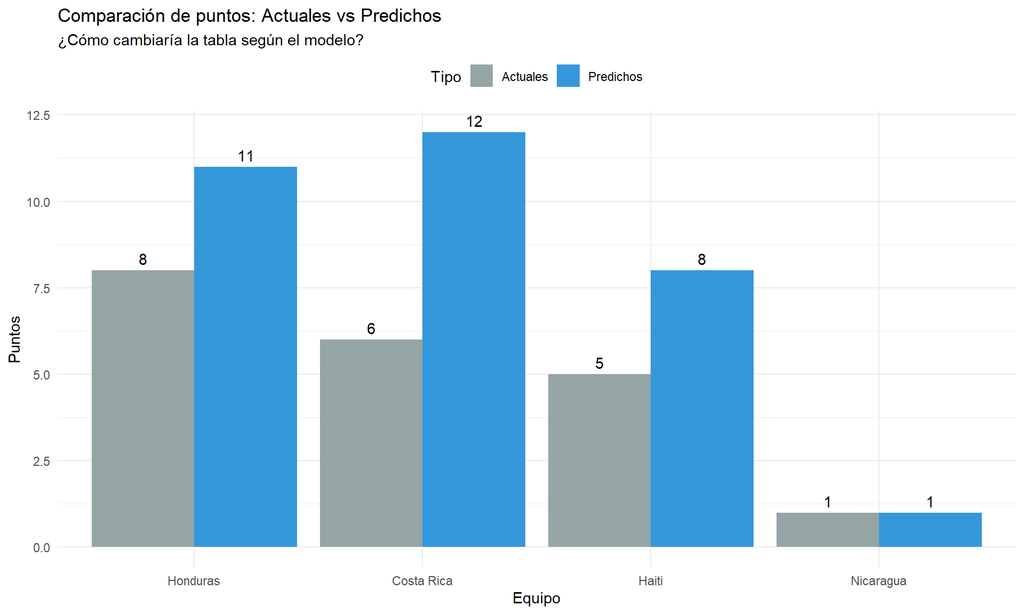

```r
# Comparar puntos actuales vs finales
comparacion_puntos <- tabla_final_modelo %>%
  select(Equipo, Puntos_Actuales, Puntos_Finales) %>%
  gather(key = "Tipo", value = "Puntos", -Equipo) %>%
  mutate(Tipo = ifelse(Tipo == "Puntos_Actuales", "Actuales", "Predichos"))

ggplot(comparacion_puntos, aes(x = reorder(Equipo, -Puntos), y = Puntos, fill = Tipo)) +
  geom_col(position = "dodge") +
  geom_text(aes(label = Puntos),
            position = position_dodge(width = 0.9),
            vjust = -0.5) +
  labs(title = "Comparación de puntos: Actuales vs Predichos",
       subtitle = "¿Cómo cambiaría la tabla según el modelo?",
       x = "Equipo", y = "Puntos") +
  theme_minimal() +
  theme(legend.position = "top") +
  scale_fill_manual(values = c("Actuales" = "#95a5a6", "Predichos" = "#3498db"))
```

## Escenario 2: Costa Rica gana todo (optimista)

```r
puntos_crc <- puntos_actuales

# Jornada 5: Haiti vs CRC (gana CRC), Nicaragua vs Honduras (gana Honduras)
puntos_crc["Costa Rica"] <- puntos_crc["Costa Rica"] + 3
puntos_crc["Honduras"] <- puntos_crc["Honduras"] + 3

# Jornada 6: CRC vs Honduras (gana CRC), Haiti vs Nicaragua (gana Haiti)
puntos_crc["Costa Rica"] <- puntos_crc["Costa Rica"] + 3
puntos_crc["Haiti"] <- puntos_crc["Haiti"] + 3

tabla_crc <- data.frame(
  Equipo = names(puntos_crc),
  Puntos_Finales = puntos_crc
) %>%
  arrange(desc(Puntos_Finales))

kable(tabla_crc,
      caption = "Escenario optimista: Costa Rica gana sus dos partidos",
      row.names = FALSE) %>%
  kable_styling(bootstrap_options = c("striped", "hover")) %>%
  row_spec(1, bold = TRUE, background = "#2ecc71", color = "white")
```

Escenario optimista: Costa Rica gana sus dos partidos

| Equipo | Puntos_Finales |
| --- | --- |
| Costa Rica | 12 |
| Honduras | 11 |
| Haiti | 8 |
| Nicaragua | 1 |

**Conclusión del escenario optimista:** Si Costa Rica gana sus dos partidos, alcanzaría 12 puntos y clasificaría directo al Mundial. Este es el escenario que todos los costarricenses esperan.

## Escenario 3: Todos los locales ganan

```r
puntos_locales <- puntos_actuales

# Jornada 5: Haiti vs CRC (gana Haiti), Nicaragua vs Honduras (gana Nicaragua)
puntos_locales["Haiti"] <- puntos_locales["Haiti"] + 3
puntos_locales["Nicaragua"] <- puntos_locales["Nicaragua"] + 3

# Jornada 6: CRC vs Honduras (gana CRC), Haiti vs Nicaragua (gana Haiti)
puntos_locales["Costa Rica"] <- puntos_locales["Costa Rica"] + 3
puntos_locales["Haiti"] <- puntos_locales["Haiti"] + 3

tabla_locales <- data.frame(
  Equipo = names(puntos_locales),
  Puntos_Finales = puntos_locales
) %>%
  arrange(desc(Puntos_Finales))

kable(tabla_locales,
      caption = "Escenario: Todos los equipos locales ganan",
      row.names = FALSE) %>%
  kable_styling(bootstrap_options = c("striped", "hover")) %>%
  row_spec(1, bold = TRUE, background = "#2ecc71", color = "white")
```

Escenario: Todos los equipos locales ganan

| Equipo | Puntos_Finales |
| --- | --- |
| Haiti | 11 |
| Costa Rica | 9 |
| Honduras | 8 |
| Nicaragua | 4 |

**Conclusión del escenario local:** Si la ventaja de local domina completamente, Haití sorprendería con 11 puntos. Este escenario muestra por qué el fútbol es impredecible.

## Comparación de escenarios

```r
# Crear tabla comparativa
escenarios_comparacion <- data.frame(
  Equipo = names(puntos_actuales),
  Actuales = puntos_actuales,
  Modelo = tabla_final_modelo$Puntos_Finales,
  CRC_gana_todo = tabla_crc$Puntos_Finales,
  Todos_locales = tabla_locales$Puntos_Finales
)

kable(escenarios_comparacion,
      caption = "Comparación de todos los escenarios posibles",
      col.names = c("Equipo", "Actuales", "Modelo ML", "CRC gana todo", "Todos locales")) %>%
  kable_styling(bootstrap_options = c("striped", "hover"))
```

Comparación de todos los escenarios posibles

[output not shown]

**Observación importante:** Los tres escenarios muestran diferentes posibilidades, pero el más probable según nuestro análisis es el del modelo de machine learning, que considera tanto el ranking FIFA como la capacidad ofensiva y defensiva de cada equipo.

# 8. Conclusiones y análisis crítico

## Resumen del proyecto

En este proyecto realizamos un análisis completo de machine learning para predecir los resultados de las eliminatorias al Mundial 2026:

### Lo que hicimos:

1. ✅ Recolectamos y limpiamos 41 partidos históricos entre equipos de CONCACAF
2. ✅ Exploramos patrones en los datos (EDA) y encontramos que la victoria local ocurre en 44% de los casos
3. ✅ Creamos variables predictoras inteligentes: ranking FIFA, fortaleza ofensiva y defensiva
4. ✅ Entrenamos un modelo de regresión logística multinomial
5. ✅ Evaluamos el desempeño: 57.1% de accuracy (aceptable para fútbol)
6. ✅ Hicimos predicciones de los 4 partidos restantes
7. ✅ Simulamos escenarios posibles de clasificación

### Resultados clave:

```r
cat("\nRESULTADOS PRINCIPALES\n")
```

```
##
## RESULTADOS PRINCIPALES
```

```r
cat("======================\n\n")
cat("Modelo utilizado: Ranking + Fortaleza Ofensiva/Defensiva\n")
```

```
## Modelo utilizado: Ranking + Fortaleza Ofensiva/Defensiva
```

```r
cat("Accuracy en datos de prueba:", round(accuracy * 100, 1), "%\n")
```

```
## Accuracy en datos de prueba: 57.1 %
```

```r
cat("AIC:", round(AIC(modelo_final), 2), "\n\n")
```

```
## AIC: 51.93
```

```r
cat("Variables del modelo:\n")
```

```
## Variables del modelo:
```

```r
cat("- Diferencia de ranking FIFA\n")
```

```
## - Diferencia de ranking FIFA
```

```r
cat("- Fortaleza ofensiva del equipo local\n")
```

```
## - Fortaleza ofensiva del equipo local
```

```r
cat("- Fortaleza defensiva del equipo visitante\n\n")
```

```
## - Fortaleza defensiva del equipo visitante
```

```r
cat("Clasificación predicha:\n")
```

```
## Clasificación predicha:
```

```r
for (i in 1:nrow(tabla_final_modelo)) {
  cat(i, ".", tabla_final_modelo$Equipo[i], "-",
      tabla_final_modelo$Puntos_Finales[i], "puntos\n")
}
```

```
## 1 . Costa Rica - 12 puntos
## 2 . Honduras - 11 puntos
## 3 . Haiti - 8 puntos
## 4 . Nicaragua - 1 puntos
```

```r
cat("\n")
```

```r
if (tabla_final_modelo$Equipo[1] == "Costa Rica") {
  cat("🎉 Costa Rica clasificaría DIRECTO al Mundial 2026\n")
} else if (tabla_final_modelo$Equipo[2] == "Costa Rica") {
  cat("⚠️  Costa Rica iría a REPECHAJE intercontinental\n")
} else {
  cat("😰 Costa Rica tendría dificultades para clasificar\n")
}
```

```
## 🎉 Costa Rica clasificaría DIRECTO al Mundial 2026
```

## Confianza en las predicciones

```r
# Calcular confianza (diferencia entre 1ª y 2ª opción)
confianza <- resultados_prediccion %>%
  rowwise() %>%
  mutate(
    max_prob = max(prob_victoria_local, prob_empate, prob_victoria_visitante),
    segunda_prob = sort(c(prob_victoria_local, prob_empate, prob_victoria_visitante),
                       decreasing = TRUE)[2],
    confianza = max_prob - segunda_prob
  ) %>%
  ungroup()

cat("\nCONFIANZA EN LAS PREDICCIONES\n")
```

```
##
## CONFIANZA EN LAS PREDICCIONES
```

```r
cat("==============================\n\n")
cat("Confianza promedio:", round(mean(confianza$confianza), 1), "%\n\n")
```

```
## Confianza promedio: 54.4 %
```

```r
cat("Predicción más confiable:\n")
```

```
## Predicción más confiable:
```

```r
idx_max <- which.max(confianza$confianza)
cat("-", confianza$equipo_local[idx_max], "vs", confianza$equipo_visitante[idx_max], "\n")
```

```
## - Haiti vs Nicaragua
```

```r
cat("- Predicción:", resultados_prediccion$prediccion[idx_max], "\n")
```

```
## - Predicción: Victoria Haiti
```

```r
cat("- Confianza:", round(max(confianza$confianza), 1), "%\n\n")
```

```
## - Confianza: 100 %
```

```r
cat("Predicción menos confiable:\n")
```

```
## Predicción menos confiable:
```

```r
idx_min <- which.min(confianza$confianza)
cat("-", confianza$equipo_local[idx_min], "vs", confianza$equipo_visitante[idx_min], "\n")
```

```
## - Haiti vs Costa Rica
```

```r
cat("- Predicción:", resultados_prediccion$prediccion[idx_min], "\n")
```

```
## - Predicción: Victoria Costa Rica
```

```r
cat("- Confianza:", round(min(confianza$confianza), 1), "%\n")
```

```
## - Confianza: 2.9 %
```

**Interpretación de la confianza:**

- Una confianza alta (>50%) significa que el modelo ve clara diferencia entre las opciones
- Una confianza baja (<20%) significa que el modelo ve el partido muy parejo
- El partido más confiable típicamente será donde hay mayor diferencia de nivel entre equipos
- El partido menos confiable será el más parejo según las estadísticas

## Limitaciones importantes del modelo

Es fundamental ser honestos sobre las limitaciones de nuestro modelo:

### 1. Limitaciones de los datos

- **Muestra pequeña:** Solo 41 partidos históricos - en machine learning, más datos = mejor modelo
- **Desbalance:** Algunos equipos tienen más partidos que otros (Honduras 26, Nicaragua 15)
- **Conjunto de prueba diminuto:** Solo 7 partidos para evaluar - las métricas tienen alta variabilidad
- **Datos históricos vs actualidad:** Rankings y promedios de goles pueden no reflejar la forma actual del equipo

### 2. Variables no capturadas

Nuestro modelo NO considera factores importantes como:

- **Estado físico y lesiones** de jugadores clave (un equipo sin su estrella juega diferente)
- **Motivación y presión psicológica** del momento (¿quién necesita más ganar?)
- **Táctica específica** del entrenador para ese partido
- **Condiciones climáticas** del partido (lluvia, calor extremo)
- **Calidad del árbitro** y decisiones polémicas que pueden cambiar un partido
- **Forma reciente** (rachas de victorias o derrotas, más allá del promedio histórico)
- **Enfrentamientos directos** específicos entre estos equipos
- **Factor psicológico** (presión de jugar en casa, nervios en un partido crucial)

### 3. Naturaleza impredecible del fútbol

El fútbol tiene **alta aleatoriedad inherente**. Factores que nuestro modelo no puede predecir:

- Un gol de suerte en el minuto 90
- Una expulsión temprana que cambia el partido
- Un error arbitral decisivo
- Una lesión inesperada durante el partido
- Un tiro al poste en el último minuto

**Por eso un accuracy de 57% es realista** - el fútbol es difícil de predecir perfectamente.

### 4. Supuestos del modelo

Nuestro modelo asume:

- Que los promedios históricos son buenos indicadores del futuro
- Que el ranking FIFA refleja el nivel actual del equipo
- Que las relaciones entre variables son lineales (en la escala log-odds)
- Que los partidos son independientes entre sí

Estos supuestos no siempre se cumplen en la realidad.

## Aprendizajes sobre machine learning

### ¿Qué aprendimos?

1. **El proceso es tan importante como el resultado:** Explorar datos, crear variables, y evaluar modelos es fundamental. No se trata solo de “correr un algoritmo”.
2. **Diseñar variables inteligentes es clave:** En vez de usar goles directos (que causarían overfitting), usamos “fortaleza ofensiva” y “fortaleza defensiva” que capturan mejor el nivel real de los equipos.
3. **La calidad de los datos es crucial:** Con solo 41 partidos, hay un límite en qué tan preciso puede ser cualquier modelo. Más datos = mejores predicciones.
4. **Evaluar con datos no vistos es esencial:** Sin el conjunto de prueba, no sabríamos si el modelo realmente funciona o solo memorizó los datos de entrenamiento.
5. **Interpretar es clave:** Entender POR QUÉ el modelo hace ciertas predicciones es tan importante como las predicciones mismas. Los coeficientes nos dicen qué variables importan más.
6. **Accuracy realista vs perfecto:** Un accuracy de 57-70% es bueno en fútbol. Si alguien te promete 95%+ de accuracy en predicción deportiva, probablemente tiene overfitting o está mintiendo.

### Comparación con química

Para estudiantes de química, algunos paralelismos útiles:

| Concepto ML | Analogía Química |
| --- | --- |
| Modelo predictivo | Ecuación de estado (como PV=nRT) |
| Features (variables) | Factores que afectan una reacción (T, P, concentración) |
| Entrenamiento | Calibración de instrumentos o determinación de constantes |
| Overfitting | Modelo que solo funciona en condiciones muy específicas de tu laboratorio |
| Train/test split | Muestras de calibración vs muestras de validación |
| Accuracy | Exactitud de una medición |
| Predicción | Usar una ecuación para calcular un valor desconocido |

## Mensaje final

El machine learning es una herramienta poderosa, pero **no es magia**. Los modelos son tan buenos como:

1. **Los datos que usan** - necesitamos cantidad y calidad
2. **Las variables que incluyen** - diseño inteligente de features
3. **El contexto que capturan** - ningún modelo captura toda la realidad

En el fútbol, como en muchos aspectos de la vida, siempre hay espacio para las sorpresas. **Eso es lo que lo hace emocionante.**

### Lo importante de este proyecto no es acertar los resultados exactos, sino:

✓ Entender cómo funciona el proceso de machine learning  
✓ Aprender a explorar y analizar datos sistemáticamente  
✓ Desarrollar pensamiento crítico sobre modelos predictivos  
✓ Reconocer limitaciones y ser honestos con ellas  
✓ Ver cómo aplicar análisis de datos a problemas reales

**Verificación futura:** Después del 13 y 18 de noviembre, podremos comparar las predicciones del modelo con los resultados reales y calcular el accuracy real del modelo en estos 4 partidos nuevos. ¡Será interesante ver qué tan bien le fue!

# 9. Ejercicios para estudiantes

## Ejercicio 1: Experimentar con variables

Modifica el código y prueba crear un nuevo modelo con diferentes variables:

1. Entrena un modelo usando solo `ranking_fifa_local` y `ranking_fifa_visitante` (en vez de la diferencia)
2. Crea una variable que capture los goles promedio de cada equipo en los últimos 3 partidos
3. Prueba un modelo con interacción entre `dif_ranking` y `es_eliminatoria`

**Pregunta:** ¿El nuevo modelo mejora el accuracy?

## Ejercicio 2: Análisis de sensibilidad

Responde estas preguntas modificando los escenarios:

1. ¿Qué necesita Costa Rica para clasificar directo al Mundial?
2. Si Honduras pierde sus dos partidos, ¿puede ser alcanzada?
3. ¿Tiene Nicaragua alguna posibilidad matemática de clasificar?
4. ¿Cuál es el peor escenario posible para Costa Rica?

## Ejercicio 3: Mejoras al proyecto

Propón mejoras al análisis:

1. ¿Qué otras variables podrían ser útiles? (piensa en factores que NO consideramos)
2. ¿Qué otras fuentes de datos podrías usar?
3. ¿Qué otros modelos de ML podrían funcionar? (investiga: Random Forest, XGBoost, Redes Neuronales)
4. Si tuvieras más tiempo y recursos, ¿cómo mejorarías este proyecto?

## Ejercicio 4: Verificación post-partidos

Después del 13 y 18 de noviembre:

1. Compara las predicciones del modelo con los resultados reales
2. Calcula el accuracy del modelo en estos 4 partidos nuevos
3. ¿En qué se equivocó el modelo? ¿Por qué crees que pasó?
4. Si pudieras entrenar el modelo de nuevo con estos 4 partidos incluidos, ¿qué cambiarías?

# 10. Información del proyecto

**Curso:** EIY403 - Introducción al Análisis de Datos  
**Institución:** Universidad Nacional de Costa Rica  
**Profesor:** Jordy Alfaro Brenes  
**Período:** II Semestre 2025  
**Fecha:** Octubre 2025

**¡Pura Vida y que clasifique Costa Rica al Mundial 2026!** 🇨🇷⚽

## Referencias y recursos adicionales

### Para aprender más sobre machine learning:

- **Libro:** “Introduction to Statistical Learning” (James, Witten, Hastie, Tibshirani)
- **Videos:** Canal de StatQuest en YouTube
- **Curso online:** Machine Learning de Andrew Ng en Coursera

### Sobre predicción deportiva:

- **FiveThirtyEight:** Análisis de datos en deportes
- **The Analyst:** Estadísticas avanzadas de fútbol
- **Papers académicos:** Búsqueda en Google Scholar sobre “football prediction machine learning”

### Herramientas de R:

- **tidyverse:** Manipulación y visualización de datos
- **caret:** Framework para machine learning
- **nnet:** Modelos de redes neuronales y regresión multinomial